# Assignment_2

Jinwoo CHA

10/11/2018

```r
library(ggplot2)
library(dplyr)
source("function_2.R")
```

```r
`%>%` <- magrittr::`%>%`
```

## Exercice 1

Test de permutation

```r
iris_subset_1 <- iris[c(89:94, 108:112),]
iris_subset_2 <- iris[c(88:114),]


permutation_iris_subset1 <- permutation_twogroups(iris_subset_1, "Sepal.Width", "Species", "versicolor",
"virginica", difference_in_medians)
permutation_iris_subset2 <- permutation_twogroups(iris_subset_2, "Sepal.Width", "Species", "versicolor",
"virginica", difference_in_medians)

mean_diff_subset1 <- difference_in_medians(iris_subset_1, "Sepal.Width", "Species", "versicolor", "virginica")
mean_diff_subset2 <- difference_in_medians(iris_subset_2, "Sepal.Width", "Species", "versicolor"," virginica")
```

```r
# vérification pour iris_subset_1
print(iris_subset_1)
```

```
##     Sepal.Length Sepal.Width Petal.Length Petal.Width    Species
## 89           5.6         3.0          4.1         1.3 versicolor
## 90           5.5         2.5          4.0         1.3 versicolor
## 91           5.5         2.6          4.4         1.2 versicolor
## 92           6.1         3.0          4.6         1.4 versicolor
## 93           5.8         2.6          4.0         1.2 versicolor
## 94           5.0         2.3          3.3         1.0 versicolor
## 108          7.3         2.9          6.3         1.8  virginica
## 109          6.7         2.5          5.8         1.8  virginica
## 110          7.2         3.6          6.1         2.5  virginica
## 111          6.5         3.2          5.1         2.0  virginica
## 112          6.4         2.7          5.3         1.9  virginica
```

```r
# vérification pour iris_subset_2
print(iris_subset_2)
```

```
##     Sepal.Length Sepal.Width Petal.Length Petal.Width    Species
## 88           6.3         2.3          4.4         1.3 versicolor
## 89           5.6         3.0          4.1         1.3 versicolor
## 90           5.5         2.5          4.0         1.3 versicolor
## 91           5.5         2.6          4.4         1.2 versicolor
## 92           6.1         3.0          4.6         1.4 versicolor
## 93           5.8         2.6          4.0         1.2 versicolor
## 94           5.0         2.3          3.3         1.0 versicolor
## 95           5.6         2.7          4.2         1.3 versicolor
## 96           5.7         3.0          4.2         1.2 versicolor
## 97           5.7         2.9          4.2         1.3 versicolor
## 98           6.2         2.9          4.3         1.3 versicolor
## 99           5.1         2.5          3.0         1.1 versicolor
## 100          5.7         2.8          4.1         1.3 versicolor
## 101          6.3         3.3          6.0         2.5  virginica
## 102          5.8         2.7          5.1         1.9  virginica
## 103          7.1         3.0          5.9         2.1  virginica
## 104          6.3         2.9          5.6         1.8  virginica
## 105          6.5         3.0          5.8         2.2  virginica
## 106          7.6         3.0          6.6         2.1  virginica
## 107          4.9         2.5          4.5         1.7  virginica
## 108          7.3         2.9          6.3         1.8  virginica
## 109          6.7         2.5          5.8         1.8  virginica
## 110          7.2         3.6          6.1         2.5  virginica
## 111          6.5         3.2          5.1         2.0  virginica
## 112          6.4         2.7          5.3         1.9  virginica
## 113          6.8         3.0          5.5         2.1  virginica
## 114          5.7         2.5          5.0         2.0  virginica
```

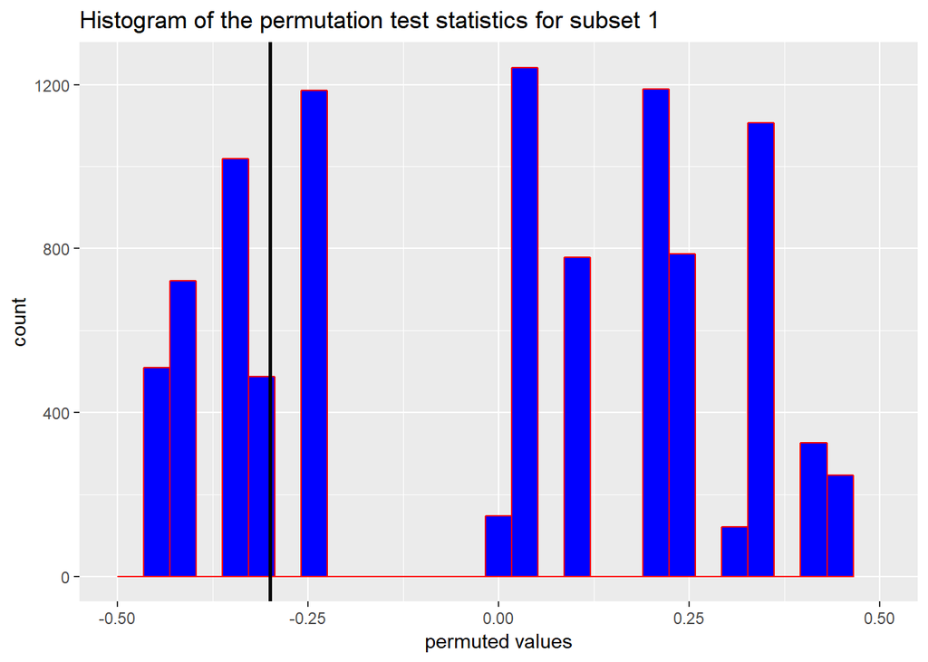

```r
observed_value_subset1 <- permutation_iris_subset1["observed"]
ptest_stats_subset1 <- tibble::as_tibble(permutation_iris_subset1["permuted"])
observed_value_subset2 <- permutation_iris_subset2["observed"]
ptest_stats_subset2 <- tibble::as_tibble(permutation_iris_subset2["permuted"])


lim_min <- min(ptest_stats_subset1, ptest_stats_subset2)
lim_max <- max(ptest_stats_subset1, ptest_stats_subset2)



ggplot2::ggplot(ptest_stats_subset1,
      ggplot2::aes(x=permuted)) + ggplot2::geom_histogram(fill=I("blue"),
      col=I("red")) + ggplot2::labs(title="Histogram of the permutation test statistics for subset 1",
                  x="permuted values",
                  y="count") + ggplot2::geom_vline(ggplot2::aes(xintercept=unlist(observed_value_subset1)),
                        show.legend = T,
                        size = 1) + ggplot2::xlim(lim_min, lim_max)
```

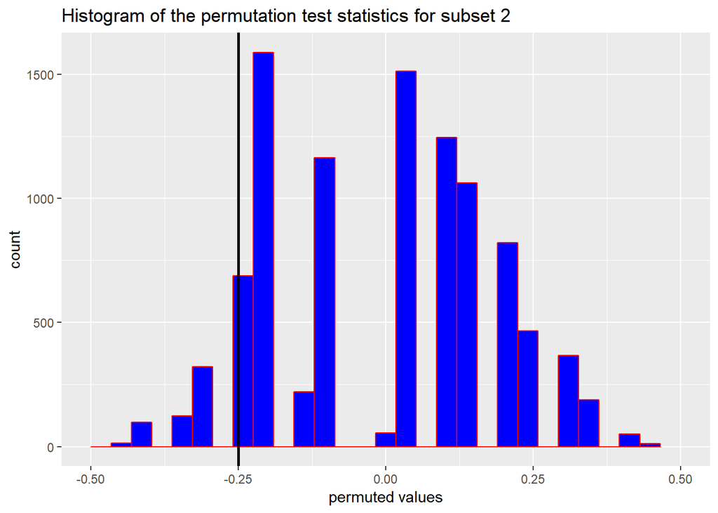

```r
ggplot2::ggplot(ptest_stats_subset2,
        aes(x=permuted)) + ggplot2::geom_histogram(fill=I("blue"),
      col=I("red")) + ggplot2::labs(title="Histogram of the permutation test statistics for subset 2",
                  x="permuted values",
                  y="count") + ggplot2::geom_vline(ggplot2::aes(xintercept=unlist(observed_value_subset2)),
                        show.legend = T,
                        size = 1) + ggplot2::xlim(lim_min, lim_max)
```

**Observation pour 2 histrogrammes** Pour subset 1, les valeurs se dispersent vers les quelques inférieures et supérieures. Mais, pour subset 2, elles se rassemblent au centre et s’étalent vers un peu dorite.

Pour subset 1, il existe de nobmreux intervalles entre les valeurs, et surtout l’intervalle est la plus grande entre -0.25 et 0. Tandis que, pour subset 2, elles distribuent plus équitable que subset 1, et l’intervalle aussi, il n’existe pas beaucoup.

Et, on peut observer le test statistiques que le subset 1 est -0.3 et que le subset 2 est -0.25. Les moyennenes sur deux dataset ne sont donc pas la même.

Le subset 1 prend 11 éléments qui composent en 6 versicolors et 5 virginicas, et le subset 2 prend 27 éléments qui composent en 13 versicolors et 14 viriginicas. c’est que pourquoi l’histogramme du subset 1 représente des données plus éparées.

**p-value**

```r
permutation_pvalue_twosided(ptest_stats_subset1$permuted, observed_value_subset1)
## [1] 0.7749
## [1] 0.2739
## [1] 0.5478
permutation_pvalue_twosided(ptest_stats_subset2$permuted, observed_value_subset2)
## [1] 0.944
## [1] 0.1249
## [1] 0.2498
```

On peut décider d’accepter ou de rejeter l’hypothèse nulle par la p-value. si la p-value est inférieur à 0.05, on peut dire d’être significative. Dans nos exemples subset 1 et subset 2, la p-value est supérieur à 0.05. Donc on ne peut pas rejeter des deux hypothèses nulles. Et, les deux subsets, les valeurs de permutation sont le plus supérieurs à leurs valeurs observées.

## Exercise 2

```r
#install.packages : "devtools"
devtools::install_github("ewan/stats_course", subdir="data/stress_shift")
```

#### Task A

```r
stress_shift_3dict <- dplyr::filter(stressshift::stress_shift_unamb, Dict=="W1802" | Dict=="J1917" | Dict=="C1687")
print(nrow(stress_shift_3dict)==451)
```

```
## [1] TRUE
```

#### Task B

```r
stress_shift_3dict_using_pipe <- stressshift::stress_shift_unamb %>%  dplyr::filter(Dict=="W1802" | Dict=="J1917" | Dict=="C1687")
identical(stress_shift_3dict, stress_shift_3dict_using_pipe)
```

```
## [1] TRUE
```

#### Task C

```r
stress_shift_3dict_nouns <- dplyr::filter(stress_shift_3dict, Category=="Noun")
stress_shift_3dict_verbs <- dplyr::filter(stress_shift_3dict, Category=="Verb")

stress_shift_3dict_using_bind <- dplyr::bind_rows(stress_shift_3dict_nouns, stress_shift_3dict_verbs)
stress_shift_3dict_using_bind_reversed <- dplyr::bind_rows(stress_shift_3dict_verbs, stress_shift_3dict_nouns)


identical(stress_shift_3dict_using_bind, stress_shift_3dict)
```

```
## [1] TRUE
```

```r
identical(stress_shift_3dict_using_bind_reversed, stress_shift_3dict)
```

```
## [1] FALSE
```

On peut savoir deux résultats que es tableaux **stress_shift_3dict_using_bind** et **stress_shift_3_dict** sont identiques, et que les tableaux **stress_shift_3dict_using_bind_reversed** et **stress_shift_3dict** ne sont pas identique. Parce que; pour le 1èr résultat, il prend la même ordre. Il est donc identique. En revanche, pour le 2ème résultat, il n’a pas l’ordre de la catégorie qui n’est pas le même. Il n’est pas donc identique.

Si je travaille avec ces données, on dois comprendre les données et l’ordre des données, et il est important l’ordre des données.

#### Task D

```r
stress_shift_nouns_renamed <- stressshift::stress_shift_unamb %>%
                              dplyr::filter(Category == "Noun") %>%
                              dplyr::select(Word, Dict, Syllable) %>%
                              dplyr::rename(Syllable_Noun = Syllable)
stress_shift_verbs_renamed <- stressshift::stress_shift_unamb %>%
                              dplyr::filter(Category == "Verb") %>%
                              dplyr::select(Word, Dict, Syllable) %>%
                              dplyr::rename(Syllable_Verb = Syllable)


stress_shift_wide <- dplyr::inner_join(stress_shift_nouns_renamed,stress_shift_verbs_renamed)
```

On a obtenu le résultat “Word” et “Dict” par la fonction **inner_join(x,y)**. Parce que la deuxième colonne se référence à la catégorie de nom ou de verbe. Donc, on traite à l’intersection de deux ensemble, les mots de chaque distionnaire appartenant à x et à y.

#### Task E

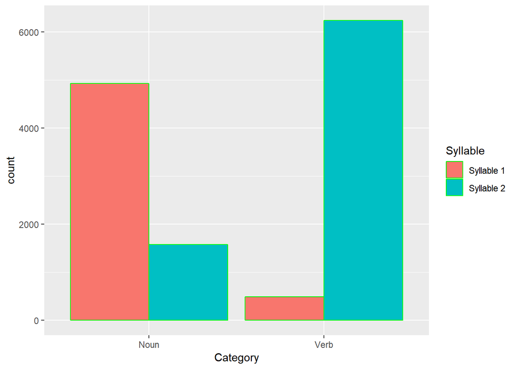

```r
ggplot2::ggplot(stressshift::stress_shift_unamb, ggplot2::aes(x=Category, fill=Syllable)) +
        ggplot2::geom_bar(position="dodge", colour="green")
```

#### Task F

```r
stress_shift_byword <- stress_shift_wide %>%
                       dplyr::group_by(Word) %>%
                       dplyr::summarise(Noun_Percent_Syll_1=  (sum(Syllable_Noun=="Syllable 1")/n())*100,
                       Verb_Percent_Syll_1=  (sum(Syllable_Verb=="Syllable 1")/n())*100)
print(nrow(stress_shift_byword)==149)
```

```
## [1] TRUE
```

#### Task G

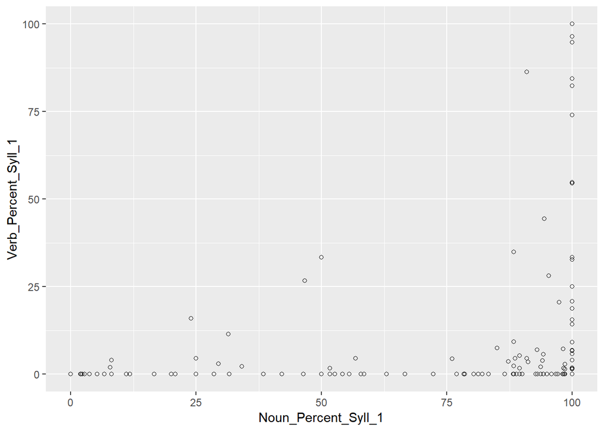

```r
ggplot2::ggplot(stress_shift_byword, ggplot2::aes(x=Noun_Percent_Syll_1, y=Verb_Percent_Syll_1)) +
    ggplot2::geom_point(shape=1)
```

### Task H

```r
stress_shift_wide_all <- dplyr::full_join(stress_shift_nouns_renamed, stress_shift_verbs_renamed)
stress_shift_byword_all <- stress_shift_wide_all %>%
  dplyr::group_by(Word) %>%
  dplyr::summarise(Noun_Percent_Syll_1=  (sum(Syllable_Noun=="Syllable 1")/n())*100,
            Verb_Percent_Syll_1=  (sum(Syllable_Verb=="Syllable 1")/n())*100)
```

## Exercise 3

```r
# creation du 1er data frame
set.seed(12)
a1 <- data.frame("group"="A", "value" = rnorm(50, 3, 2))
b1 <- data.frame("group"="B", "value" = rnorm(50, 4, 2))
data1 <- dplyr::bind_rows(a1, b1)
set.seed(NULL)
```

```r
# t-test
t.test(a1$value, b1$value)
```

```
##
##  Welch Two Sample t-test
##
## data:  a1$value and b1$value
## t = -4.196, df = 97.99, p-value = 5.974e-05
## alternative hypothesis: true difference in means is not equal to 0
## 95 percent confidence interval:
##  -2.1314085 -0.7626793
## sample estimates:
## mean of x mean of y
##  2.714141  4.161185
```

**Explication 1** On peut savoir que La t-value est -4.196 et le df est 97.99. C’est ici où on epeut dire qu’il est significative car la p-value est 5.974e-05.  
Donc, on ne peut pas adopter l’hypothèse nulle car la p-value est inférieure à 0.05.  
L’écart maximal de la moyenne peut être aussi faible que -2.13 et aussi élevé que -0.76 Et, il montre également que l’échantillon de la moyenne pour x, est 2.714141, et celle pour y, est 4.161185.

Maintenant on fait encore le t-test avec 5 sample dans le chaque groupe

```r
# creation du 2ème data frame
set.seed(12)
a2 <- data.frame("group"="A", "value" = rnorm(5, 3, 2))
b2 <- data.frame("group"="B", "value" = rnorm(5, 4, 2))
data2 <- dplyr::bind_rows(a2, b2)
set.seed(NULL)
```

```r
t.test(a2$value, b2$value)
```

```
##
##  Welch Two Sample t-test
##
## data:  a2$value and b2$value
## t = -1.6835, df = 4.6325, p-value = 0.1577
## alternative hypothesis: true difference in means is not equal to 0
## 95 percent confidence interval:
##  -5.521426  1.214674
## sample estimates:
## mean of x mean of y
##  1.488884  3.642260
```

Pour l’expérience 1, on rejete l’hypothèse nulle, tandis que, pour l’expérience 2, on l’adapte car la p-value est supéirue à 0.05.

#### Histogramme 1 sur hypothèse nuelle (50)

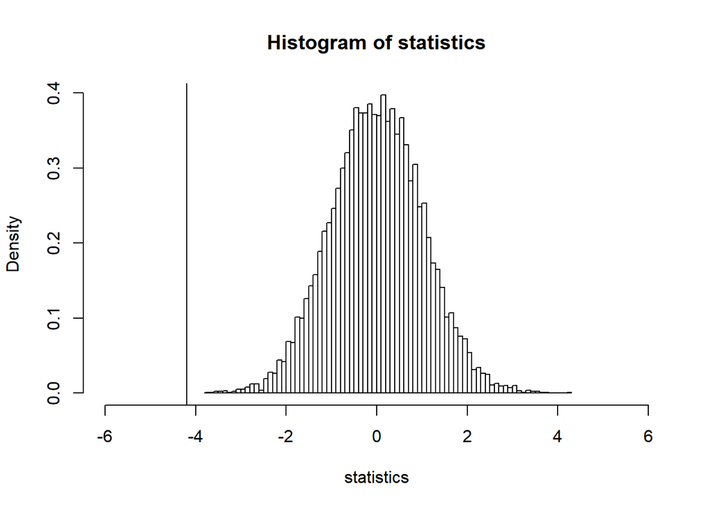

```r
overall_mean <- mean(c(a1$value,b1$value))

N_SAMPLES <- 9999
statistics <- rep(NA, N_SAMPLES)
for (i in 1:N_SAMPLES) {
  A_h0 <- rnorm(50, overall_mean, 2)
  B_h0 <- rnorm(50, overall_mean, 2)
  statistics[i] <- permutation_t_test(A_h0, B_h0)
}

hist(statistics, freq=FALSE, breaks=80, xlim=c(-6,6))
abline(v=permutation_t_test(a1$value,b1$value))
```

on peut observer que la distribution empirique est 0. Donc, on peut rejeter l’hypothèse nulle car on ne peut pas verifier la valeur t qui n’est pas graphiquement dans la distribution de la variable de t-test.

### Histrogramme 2 sur hypothèse nulle (5)

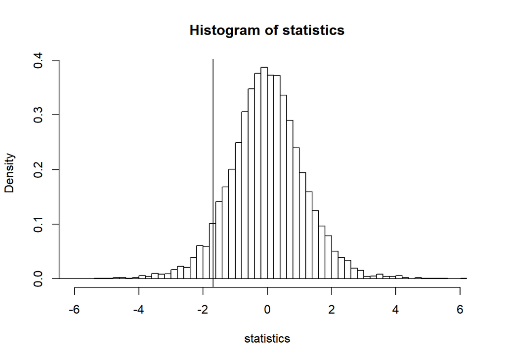

```r
overall_mean <- mean(c(a2$value,b2$value))

N_SAMPLES <- 9999
statistics <- rep(NA, N_SAMPLES)
for (i in 1:N_SAMPLES) {
  A_h0 <- rnorm(5, overall_mean, 2)
  B_h0 <- rnorm(5, overall_mean, 2)
  statistics[i] <- permutation_t_test(A_h0, B_h0)
}

hist(statistics, freq=FALSE, breaks=80, xlim=c(-6,6))
abline(v=permutation_t_test(a2$value,b2$value))
```

On peut savoir le fait que la valeur t soit dans la distribution de la variable de t-test.

# Exercise 4

```r
# Conditions :

sample_sizes <- c(5,50)
means <- c(1,2)
stardard_deviations <- c(2,6)

alpha <- 0.01
power_df <- NULL
for (size in sample_sizes){
  for (mean in means){
    for (deviation in stardard_deviations){
      n_successes <- 0
      for(i in 1:1000){
          a <- data.frame("group"= "A", "value" = rnorm(size, mean, deviation))
          b <- data.frame("group"= "B", "value" = rnorm(size, mean, deviation))
          p_value <- t.test(a$value, b$value)$p.value
          if (p_value < 0.05){n_successes <- n_successes + 1}
          }
          power <- n_successes / 1000
          power_df_current <- tibble::data_frame(power=power,
                                                 size=size,
                                                 mean=mean,
                                                 deviation=deviation)
          power_df <- dplyr::bind_rows(power_df, power_df_current)
    }
  }
}
```

#### Plotting results

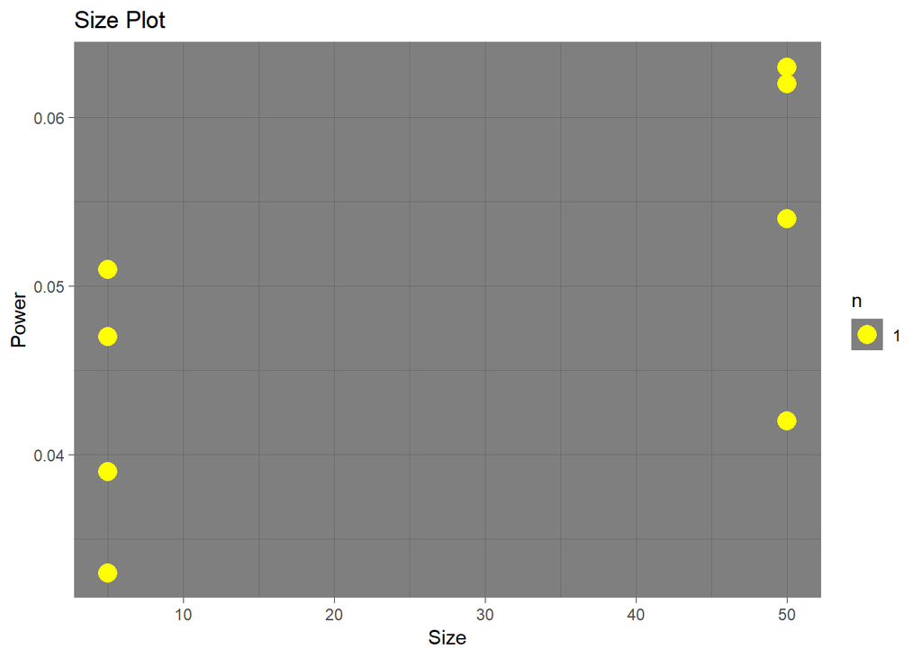

```r
ggplot2::ggplot(power_df,
                ggplot2::aes(x=size, y=power)) +
                ggplot2::labs(title="Size Plot", x="Size", y="Power") +
                ggplot2::geom_count(colour="yellow") +
                ggplot2::theme_dark()
```

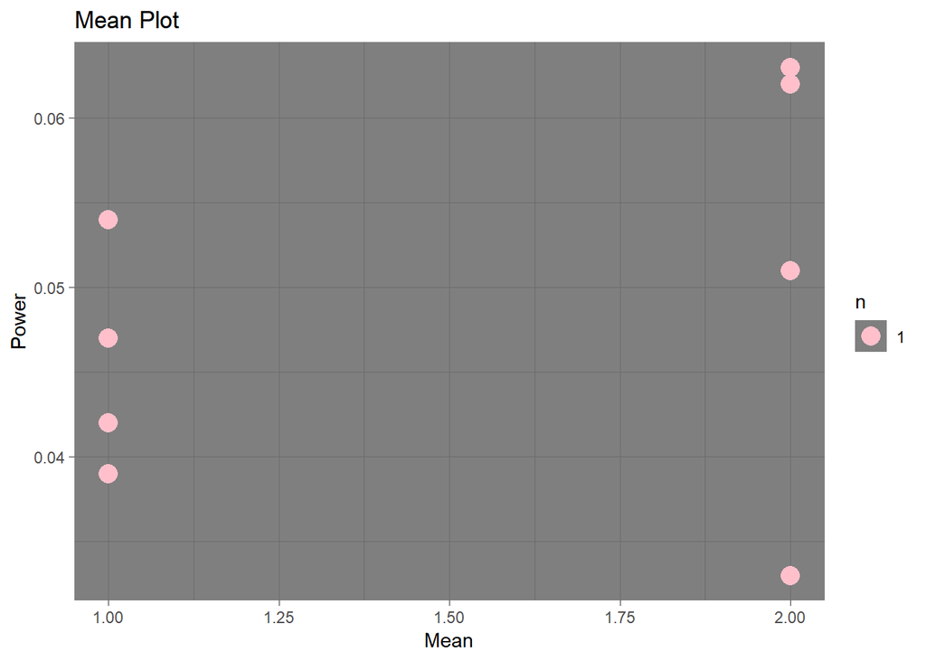

```r
ggplot2::ggplot(power_df,
                ggplot2::aes(x=mean, y=power)) +
                ggplot2::labs(title="Mean Plot", x="Mean", y="Power") +
                ggplot2::geom_count(colour="pink")+
                ggplot2::theme_dark()
```

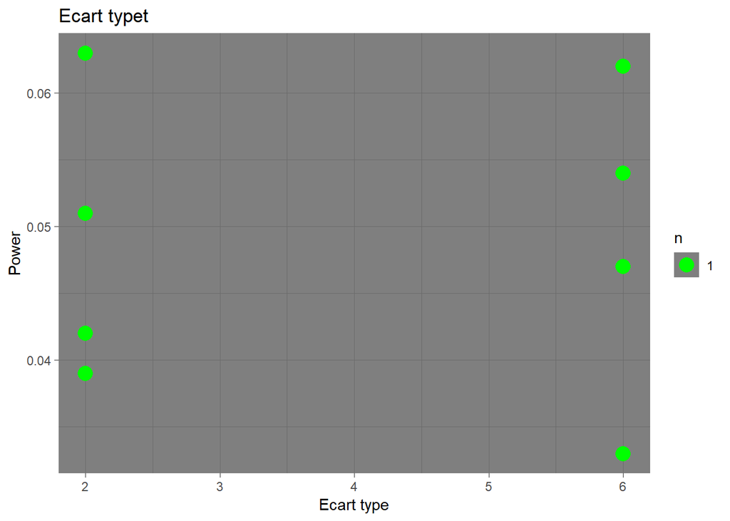

```r
ggplot2::ggplot(power_df,
                ggplot2::aes(x=deviation, y=power)) +
                ggplot2::labs(title="Ecart typet", x="Ecart type", y="Power") +
                ggplot2::geom_count(colour="green")+
                ggplot2::theme_dark()
```